# Day-02: Principal Components Analysis (PCA) and Visualizing Shape Differences

## **Content Description**

Here we demonstrate some of the graphical capabilities of `geomorph` for visualizing patterns of shape variation and interpreting particular shape differences.

First, let´s load some example data and plot the specimens (before and after GPA alignment):

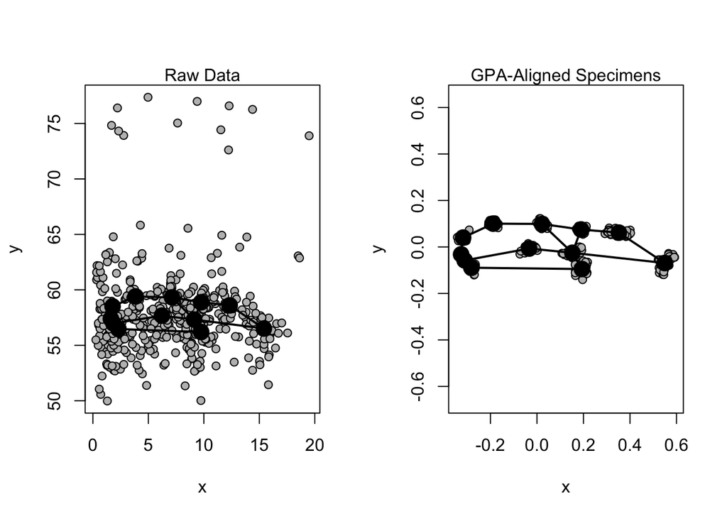

```r
library(geomorph)
data(plethodon)
Y.gpa <- gpagen(plethodon$land, print.progress = F)    # GPA-alignment

par(mfrow=c(1,2))
plotAllSpecimens(plethodon$land, links=plethodon$links)  # Raw data
mtext("Raw Data")
plotAllSpecimens(Y.gpa$coords, links=plethodon$links)    # GPA-aligned data
mtext("GPA-Aligned Specimens")
```

```r
par(mfrow=c(1,1))
```

## **1: Principal Components Analysis**

The function `gm.prcomp` provides visualization of patterns of data in shape space via PCA (and as we’ll see later, via other data alignment procedures). Here is a simple example of use of the function:

```r
PCA <- gm.prcomp(Y.gpa$coords)
summary(PCA)
```

```
##
## Ordination type: Principal Component Analysis
## Centering by OLS mean
## Orthogonal projection of OLS residuals
## Number of observations: 40
## Number of vectors 20
##
## Importance of Components:
##                              Comp1       Comp2        Comp3        Comp4
## Eigenvalues            0.001855441 0.001566597 0.0004141056 0.0002278444
## Proportion of Variance 0.367433295 0.310233333 0.0820053761 0.0451200584
## Cumulative Proportion  0.367433295 0.677666628 0.7596720044 0.8047920628
##                               Comp5        Comp6        Comp7        Comp8
## Eigenvalues            0.0001725997 0.0001672575 0.0001549008 0.0001251132
## Proportion of Variance 0.0341799312 0.0331220169 0.0306750315 0.0247761773
## Cumulative Proportion  0.8389719940 0.8720940109 0.9027690424 0.9275452197
##                               Comp9       Comp10       Comp11       Comp12
## Eigenvalues            8.468503e-05 6.869926e-05 5.430853e-05 4.423148e-05
## Proportion of Variance 1.677019e-02 1.360452e-02 1.075473e-02 8.759165e-03
## Cumulative Proportion  9.443154e-01 9.579199e-01 9.686747e-01 9.774338e-01
##                              Comp13       Comp14       Comp15       Comp16
## Eigenvalues            0.0000261742 0.0000192644 1.741769e-05 1.715141e-05
## Proportion of Variance 0.0051832795 0.0038149309 3.449226e-03 3.396495e-03
## Cumulative Proportion  0.9826170994 0.9864320303 9.898813e-01 9.932778e-01
##                              Comp17       Comp18       Comp19       Comp20
## Eigenvalues            1.555244e-05 9.253679e-06 5.336746e-06 3.802714e-06
## Proportion of Variance 3.079853e-03 1.832507e-03 1.056837e-03 7.530520e-04
## Cumulative Proportion  9.963576e-01 9.981901e-01 9.992469e-01 1.000000e+00
```

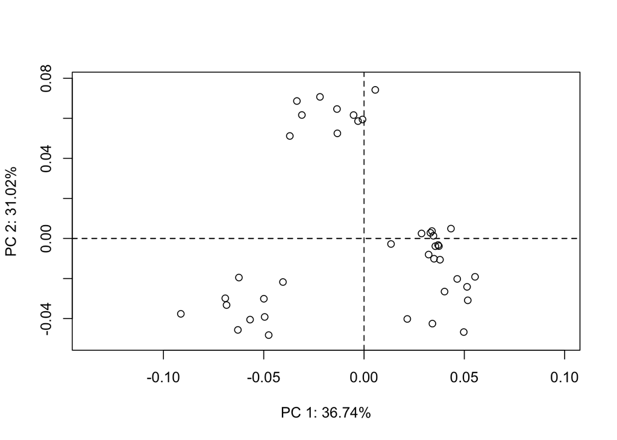

```r
plot(PCA)
```

Here we have summarized variation along each PC axis, and provided a plot. Here is a more advanced version:

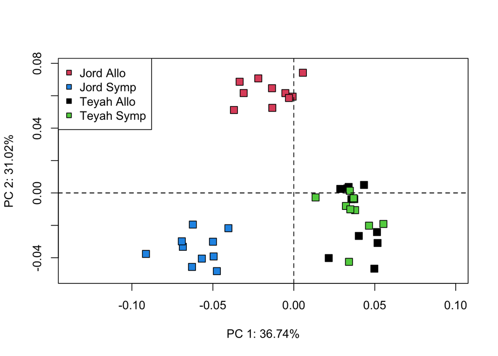

```r
gps <- as.factor(paste(plethodon$species, plethodon$site))  #define some groups for plotting
plot(PCA, pch=22, cex = 1.5, bg = gps)
legend("topleft", pch=22, pt.bg = unique(gps), legend = levels(gps))
```

## **2: Visualize Shape Differences Between Specimens**

Taking the previous example, we may now with to generate graphical depictions of shape *differences* for certain specimens. Generating graphical depictions of shapes is accomlished using `plotRefToTarget`. Here are a few examples of its use:

### Deformations Specimen to Specimen

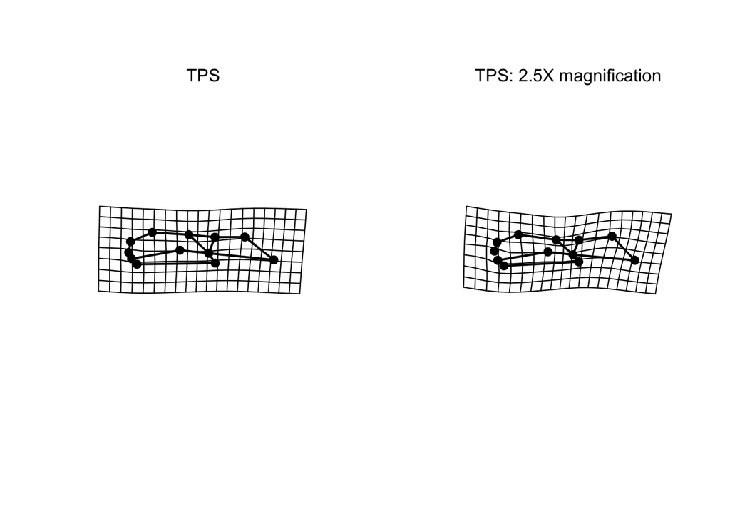

```r
M <- mshape(Y.gpa$coords)

par(mfrow=c(1,2))
plotRefToTarget(M,Y.gpa$coords[,,39], links=plethodon$links)
mtext("TPS")
plotRefToTarget(M,Y.gpa$coords[,,39], mag=2.5, links=plethodon$links)
mtext("TPS: 2.5X magnification")
```

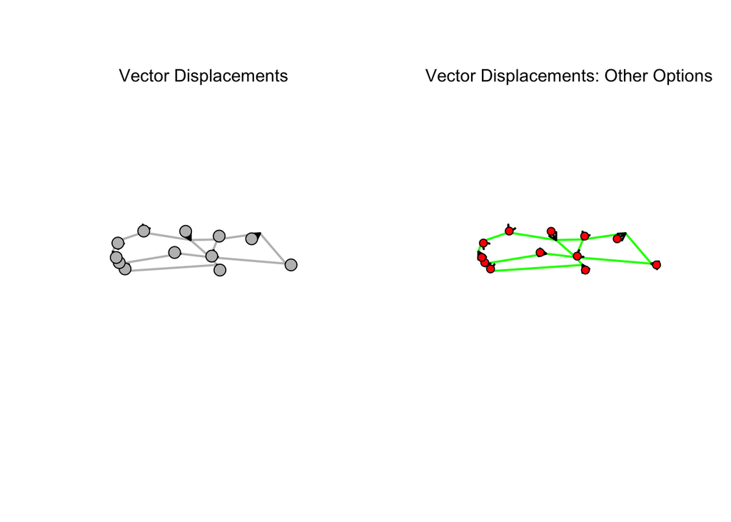

```r
par(mfrow=c(1,1))

par(mfrow=c(1,2))
plotRefToTarget(M,Y.gpa$coords[,,39], links=plethodon$links, method="vector", mag=3)
mtext("Vector Displacements")
plotRefToTarget(M,Y.gpa$coords[,,39], links=plethodon$links,gridPars=gridPar(pt.bg="red", link.col="green", pt.size = 1), method="vector", mag=3)
mtext("Vector Displacements: Other Options")
```

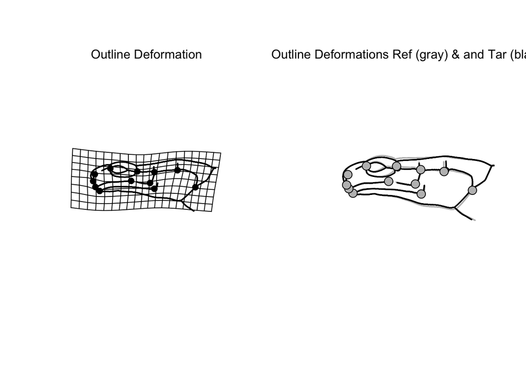

```r
par(mfrow=c(1,1))

par(mfrow=c(1,2))
plotRefToTarget(M,Y.gpa$coords[,,39], mag=2, outline=plethodon$outline)
mtext("Outline Deformation")
plotRefToTarget(M,Y.gpa$coords[,,39], method="points", outline=plethodon$outline)
mtext("Outline Deformations Ref (gray) & and Tar (black)")
```

```r
par(mfrow=c(1,1))
```

## **3: Advanced Shape Plotting: Shape Prediction**

NOw let’s visualize how shape changes along PC1 of the previous ordination. For this we must *PREDICT* shapes along PC1, and then plot them. This is accomplished using a combination of the functions `shape.predictor` (to identify shapes along PC1), and `plotRefToTarget` (to visualize them):

### PCA Shape Predictions

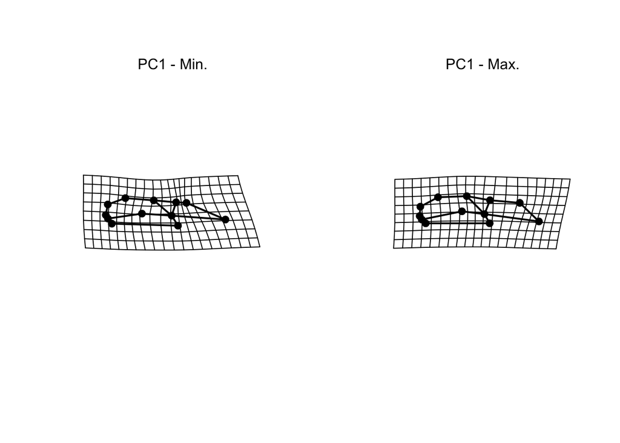

```r
PC <- PCA$x[,1]
preds <- shape.predictor(Y.gpa$coords, x= PC, Intercept = FALSE,
                         pred1 = min(PC), pred2 = max(PC)) # PC 1 extremes, more technically
par(mfrow=c(1,2))
plotRefToTarget(M, preds$pred1, links = plethodon$links)
mtext("PC1 - Min.")
plotRefToTarget(M, preds$pred2, links = plethodon$links)
mtext("PC1 - Max.")
```

```r
par(mfrow=c(1,1))
```

### Shape Predictions Along a Regression

Many times, we fit a linear model in the form of regression (e.g., allometry). Here is how we visualize shape changes along the extremes of that regression using `shape.predictor`:

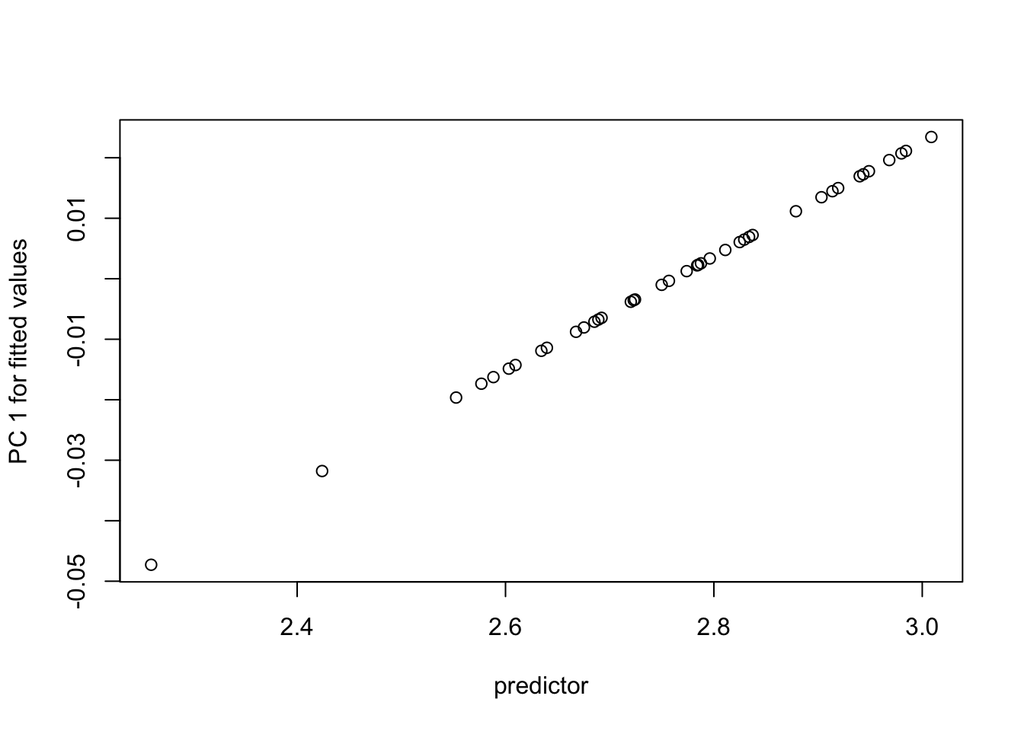

```r
gdf <- geomorph.data.frame(Y.gpa)
plethAllometry <- procD.lm(coords ~ log(Csize), data=gdf, print.progress = FALSE)
allom.plot <- plot(plethAllometry,
                   type = "regression",
                   predictor = log(gdf$Csize),
                   reg.type ="PredLine") # make sure to have a predictor
```

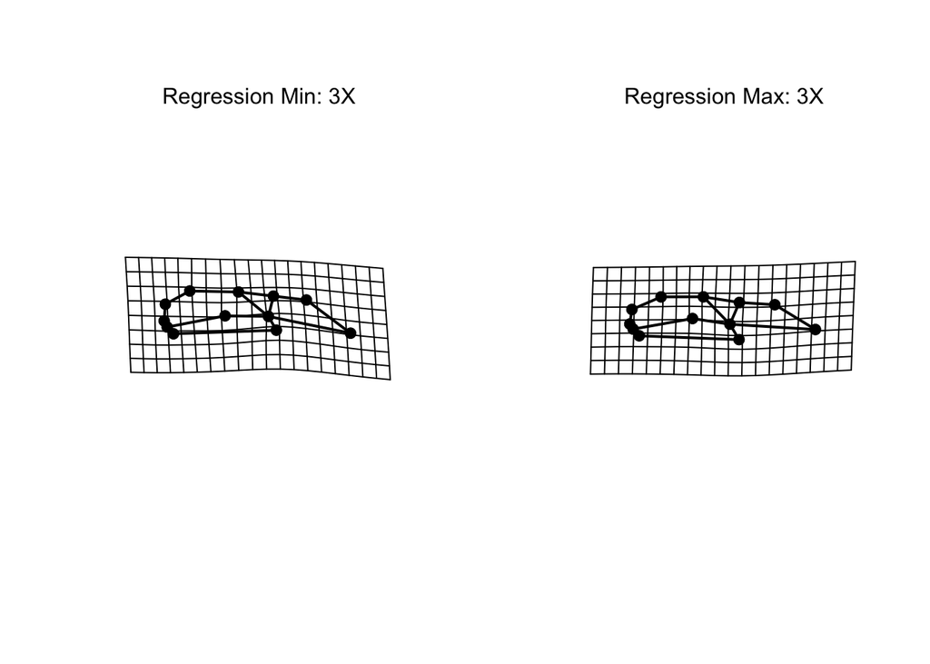

```r
preds <- shape.predictor(plethAllometry$GM$fitted, x= allom.plot$RegScore, Intercept = TRUE,
                         predmin = min(allom.plot$RegScore),
                         predmax = max(allom.plot$RegScore))
par(mfrow=c(1,2))
plotRefToTarget(M, preds$predmin, mag=3, links = plethodon$links)
mtext("Regression Min: 3X")
plotRefToTarget(M, preds$predmax, mag=3, links = plethodon$links)
mtext("Regression Max: 3X")
```

```r
par(mfrow=c(1,1))
```

### Shape Predictions of Group Differences

Another very common statistical design is one of evaluating group differences in shape (i.e., ANOVA). Here we wish to visualize shape differences among groups. Below is an example:

```r
gdf <- geomorph.data.frame(Y.gpa, species = plethodon$species, site = plethodon$site)
pleth.anova <- procD.lm(coords ~ species*site, data=gdf, print.progress = FALSE)
X <- pleth.anova$X
X # includes intercept; remove for better functioning
```

```
##    (Intercept) speciesTeyah siteSymp speciesTeyah:siteSymp
## 1            1            0        1                     0
## 2            1            0        1                     0
## 3            1            0        1                     0
## 4            1            0        1                     0
## 5            1            0        1                     0
## 6            1            0        1                     0
## 7            1            0        1                     0
## 8            1            0        1                     0
## 9            1            0        1                     0
## 10           1            0        1                     0
## 11           1            1        1                     1
## 12           1            1        1                     1
## 13           1            1        1                     1
## 14           1            1        1                     1
```

[output cut: 26 more lines]

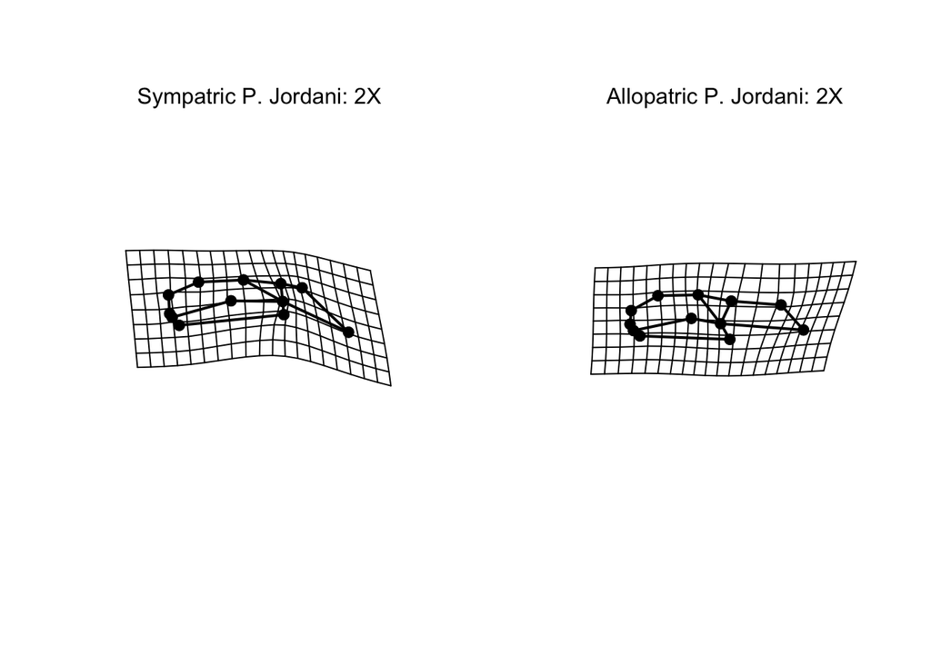

```r
X <- X[,-1]
symJord <- c(0,1,0) # design for P. Jordani in sympatry
alloJord <- c(0,0,0) # design for P. Jordani in allopatry
preds <- shape.predictor(arrayspecs(pleth.anova$fitted, 12, 2), x = X, Intercept = TRUE,
                         symJord=symJord, alloJord=alloJord)
par(mfrow=c(1,2))
plotRefToTarget(M, preds$symJord, links = plethodon$links, mag=2)
mtext("Sympatric P. Jordani: 2X")
plotRefToTarget(M, preds$alloJord, links = plethodon$links, mag=2)
mtext("Allopatric P. Jordani: 2X")
```

```r
par(mfrow=c(1,1))
```

## **4: Selecting Shapes to Visualize in Real Time**

One recent enhancement of `geomorph` is the `picknplot.shape` function. With this function, one can select locations in a statistical dataspace, and `geomorph` will mathematially back-translate the statistical summary values in the plot to obtain landmark coordinates, and will then generate a thin-plate spline deformation grid of a specimen that would exist at that location in the dataspace.

This real-time visualization is especially useful for viewing regions of morphospace that are unoccupied by the sample of specimens, and for exploring other non-sampled shapes.

##### Note: because this is an interactive function, the code is repeated below but not run.

```r
# 2d
# data(plethodon)
# Y.gpa <- gpagen(plethodon$land)
# pleth.pca <- gm.prcomp(Y.gpa$coords)
# pleth.pca.plot <- plot(pleth.pca)
# picknplot.shape(pleth.pca.plot)
# May change arguments for plotRefToTarget
# picknplot.shape(plot(pleth.pca), method = "points", mag = 3, links=plethodon$links)
```

## **5: 3D warping**

`Geomorph` also has the ability to generate shape deformations of 3D objects. Again this is interactive code, so it is repeated, but not run, below:

```r
#scallops <- readland.tps("Data/scallops for viz.tps", specID = "ID")
#ref <- mshape(scallops)
#refmesh <- warpRefMesh(read.ply("Data/glyp02L.ply"),
#                       scallops[,,1], ref, color=NULL, centered=T)
#PCA.scallop <- gm.prcomp(scallops)
#PC.sc <- PCA.scallop$x[,1]
#sc.preds <- shape.predictor(scallops, x= PC.sc, Intercept = FALSE,
#                         pred1 = min(PC.sc), pred2 = max(PC.sc)) # PC 1 extremes, more technically
#plotRefToTarget(ref, sc.preds$pred1)
#plotRefToTarget(ref, sc.preds$pred2)

#plotRefToTarget(ref, sc.preds$pred1, mesh = refmesh, method = "surface", mag = 1)
#plotRefToTarget(ref, sc.preds$pred2, mesh = refmesh, method = "surface", mag = 1)
```